# Homework 7 Part I

Allyson Wood

10/7/2019

# Horseshoe Crabs

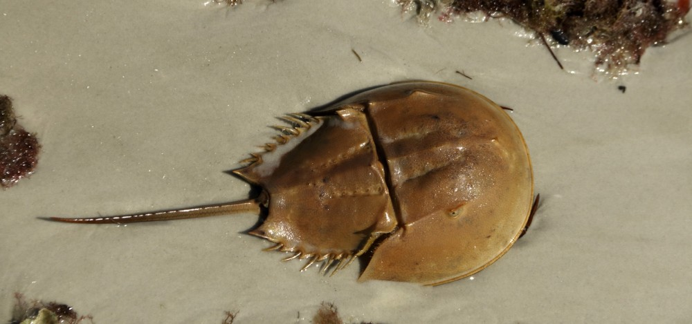

## Introduction

Horseshoe crabs arrive on the beach in pairs and spawn … during … high tides. Unattached males also come to the beach, crowd around the nesting couples and compete with attached males for fertilizations. Satellite males form large groups around some couples while ignoring others, resulting in a nonrandom distribution that cannot be explained by local environmental conditions or habitat selection.” (Brockmann, H. J. (1996) Satellite Male Groups in Horseshoe Crabs, Limulus polyphemus, Ethology, 102, 1–21. )

### Data

We have a data set about 173 mating female crabs. Data collected included whether or not a male satellite was present (and how many if present) and the color, spine condition, weight, and carapace width of the female crab.

|  | Color | Spine Condition | Carapace Width | Satellites Present | Weight | Satellite Indicator |
| --- | --- | --- | --- | --- | --- | --- |
| 1 | medium | Both Worn/Broken | 28.3 | 8 | 3050 | At least 1 Satellite |
| 2 | dark | Both Worn/Broken | 22.5 | 0 | 1550 | No Satellite |
| 3 | light | Both Good | 26 | 9 | 2300 | At least 1 Satellite |
| 4 | dark | Both Worn/Broken | 24.8 | 0 | 2100 | No Satellite |
| 5 | dark | Both Worn/Broken | 26 | 4 | 2600 | At least 1 Satellite |
| 6 | medium | Both Worn/Broken | 23.8 | 0 | 2100 | No Satellite |
| 7 | light | Both Good | 26.5 | 0 | 2350 | No Satellite |
| 8 | dark | One Worn/Broken | 24.7 | 0 | 1900 | No Satellite |
| 9 | medium | Both Good | 23.7 | 0 | 1950 | No Satellite |
| 10 | dark | Both Worn/Broken | 25.6 | 0 | 2150 | No Satellite |

[output cut: 163 more lines]

## Numeric Summaries

We’ll consider three categorical variables from the data set: female color, spine condition, and whether or not a satellite was present.

### Full table

This table displays the number of female crabs by color and spine condition. The majority have medium colored shells, and most of them have shells that are both worn or broken.

Color and Spine condition information

|  | Both Good | One Worn/Broken | Both Worn/Broken |
| --- | --- | --- | --- |
| light | 9 | 2 | 1 |
| medium | 24 | 8 | 63 |
| dark | 3 | 4 | 37 |
| darker | 1 | 1 | 20 |

### Table by Satellite Indicator

The first table displays the number of female crabs that have no satellite by color and spine condition. The second table displays the number of female crabs that have at least one satellite by color and spine condition. More female crabs have at least one satellite. Most of the female crabs in both groups are female-colored and have two worn or broken shells.

For female crabs with no satellite:

|  | Both Good | One Worn/Broken | Both Worn/Broken |
| --- | --- | --- | --- |
| light | 2 | 0 | 1 |
| medium | 8 | 5 | 13 |
| dark | 0 | 2 | 16 |
| darker | 1 | 1 | 13 |

For female crabs with at least one satellite:

|  | Both Good | One Worn/Broken | Both Worn/Broken |
| --- | --- | --- | --- |
| light | 7 | 2 | 0 |
| medium | 16 | 3 | 50 |
| dark | 3 | 2 | 21 |
| darker | 0 | 0 | 7 |

## Visuals

### One Variable

The first bar chart shows the number of crabs with each shell color. Medium-colored crabs make up the majority. The second bar chart shows the number of crabs that have each type of spine condition. The majority of crabs have two worn or broken shells. The third bar chart shows the number of female crabs with no satellite compared to those with at least one satellite. Most of the female crabs have at least one satellite.

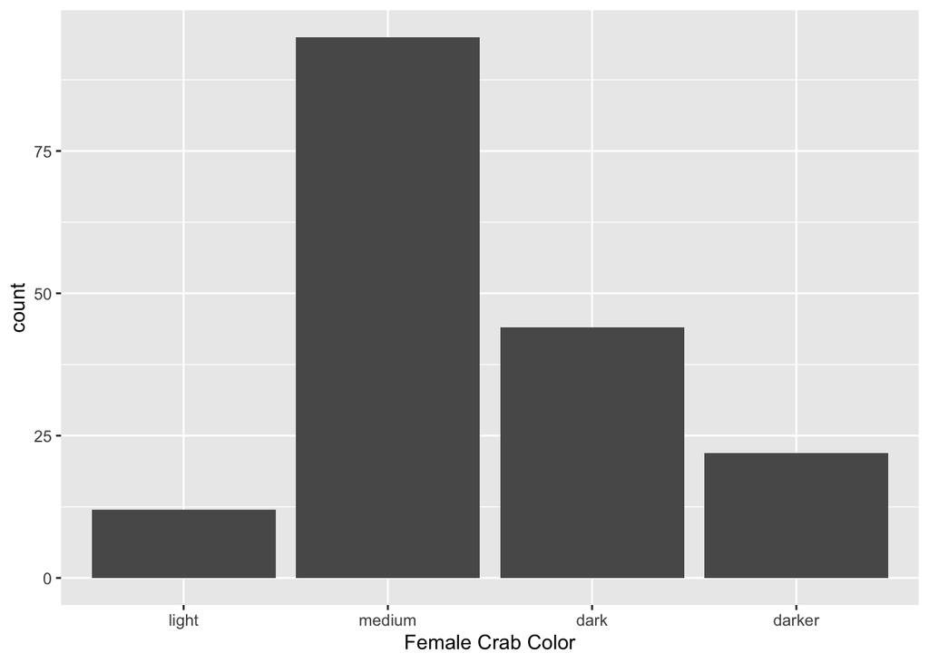

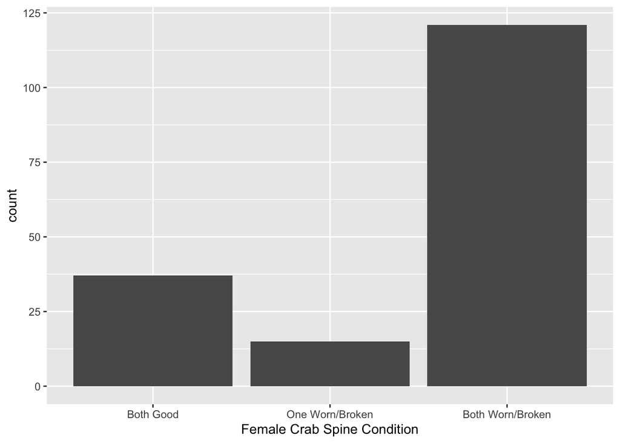

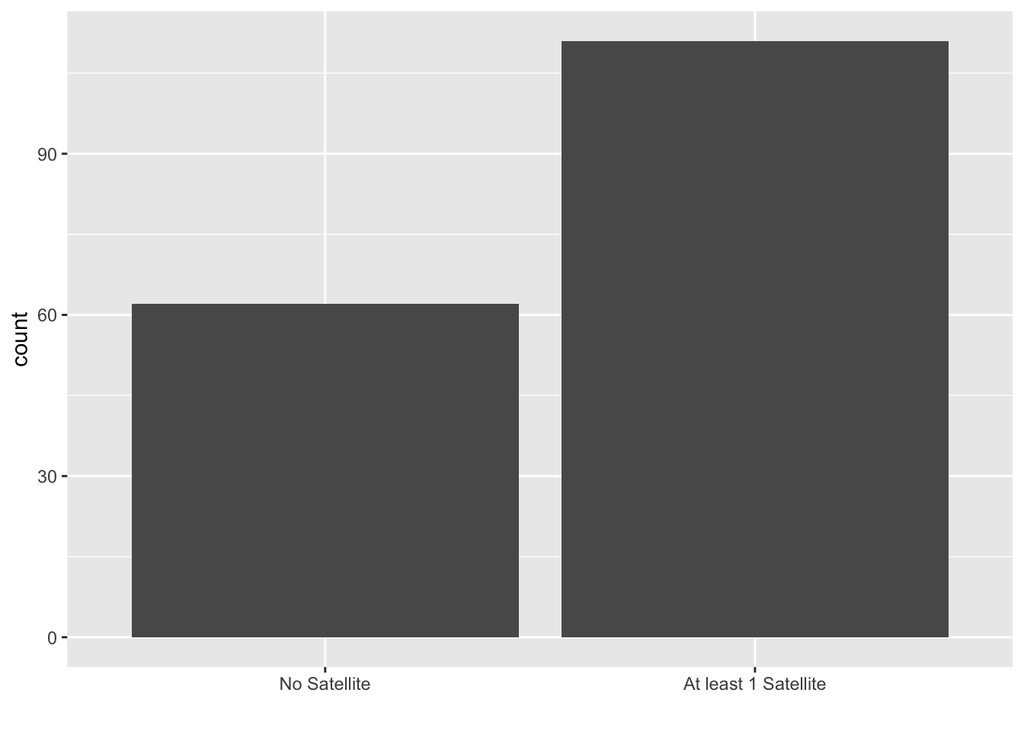

### Two Variables

The first chart shows the number of female crabs by color and satellite indicator. Among the light, medium, and dark colored crabs, those with at least one satellite occur more frequently, whereas more of the darker colored crabs have no satellite. The second chart shows the number of female crabs by spine condition and satellite indicator. Crabs with only one worn/broken spine are pretty evenly split between having a satellite or not. For the other two spine conditions, those with at least one satellite outnumber those without a satellite. The third chart shows the number of female crabs by color and spine condition. Medium-colored crabs make up the largest group within each spine condition.

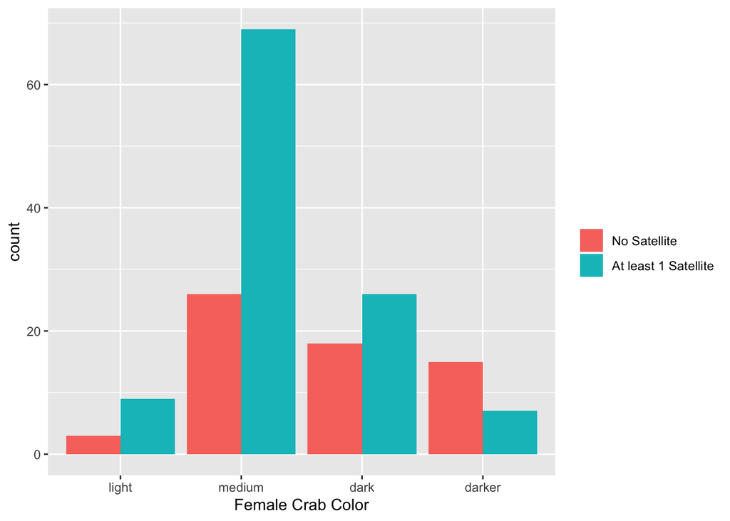

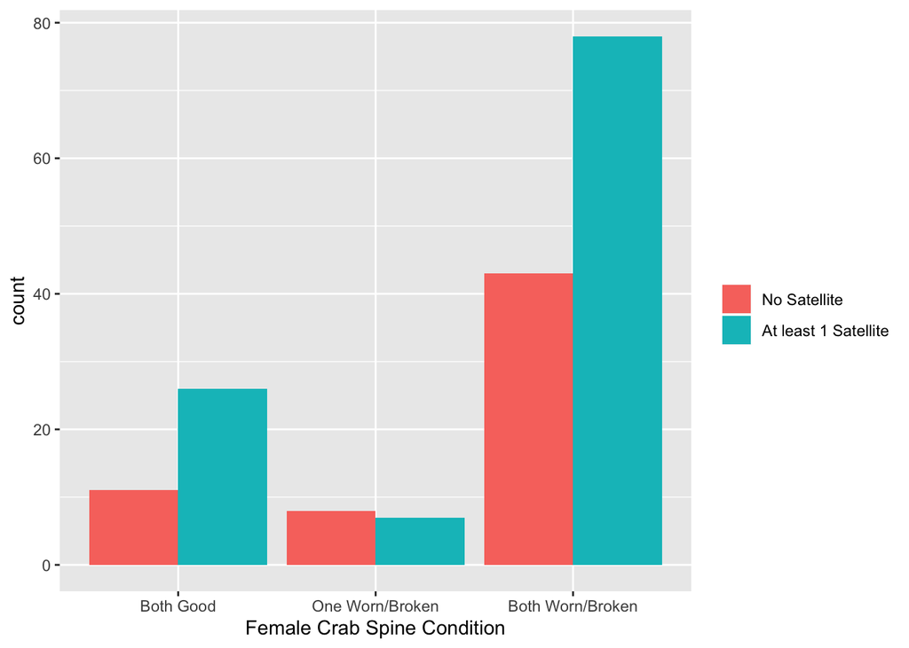

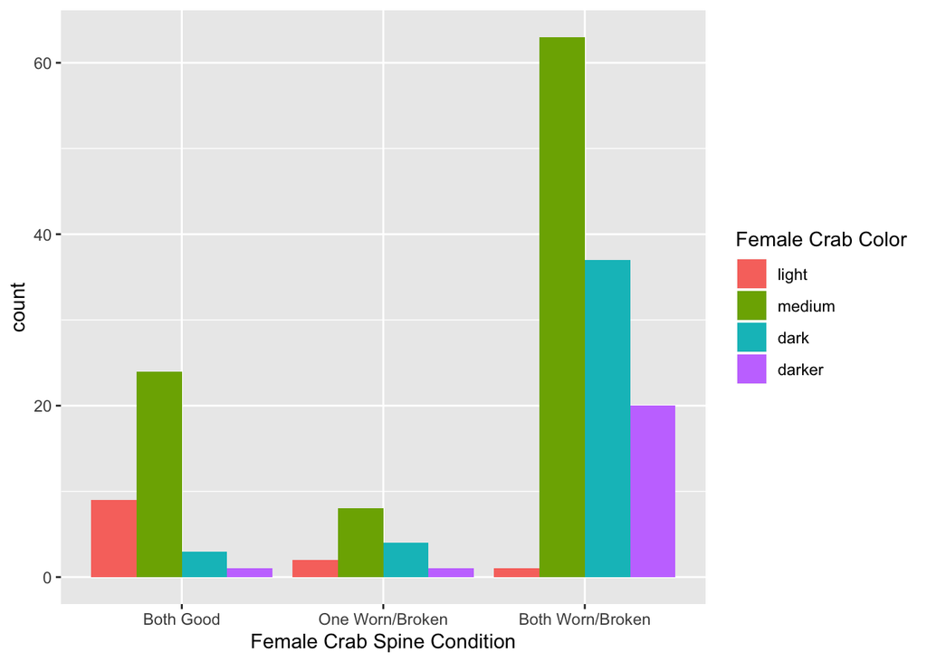

### Three Variables

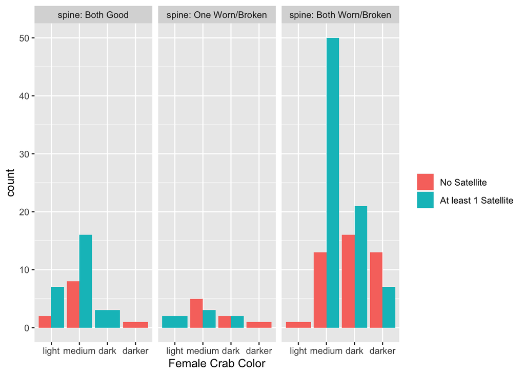